# Customer Phone Calls - Solution

www.PredictiveInsightsAI.com Solution to SOA PA 6/18/20

13 October, 2020

For your convenience, this solution document has been formatted to be easy to read. When taking this exam, candidates are not expected to make their `.Rmd` documents look this way. The `make_table` function is included only to improve your reading experience. The SOA’s instructions from the Project Statement say only that

> At a minimum you must submit your completed report template and an Rmd file that supports your work. Graders expect that your Rmd code can be run from beginning to end. The code snippets provided should either be commented out or adapted for execution. Ensure that it is clear where in the code each of the tasks is addressed. Documentation of your thought process and conclusion for each task should be completely contained within your Word report. The Rmd code should be clear, may contain commentary, and support your work.

# Task 1: Explore the data

```r
#NO CHANGES NEEDED
# Load needed libraries.
library(ggplot2)
library(dplyr)
library(tidyr)
library(caret)
library(kableExtra) #If needed, install this package.  It's just used for making tables.
library(ExamPAData)

theme_set(theme_minimal())

#function to create html tables
make_table <- function(df, caption = ""){
  df %>%
    kable(caption = caption) %>%
    kable_styling(bootstrap_options = "striped", full_width = F)}

#global chunk options
knitr::opts_chunk$set(warning = F, message = F, echo = T, fig.width = 14, fig.height = 8, dev.args = list(type = "cairo"))
```

```r
# Read the data.
df <- customer_phone_calls

summary(df)
```

```
##       age            job              marital            housing
##  Min.   :17.00   Length:10000       Length:10000       Length:10000
##  1st Qu.:31.00   Class :character   Class :character   Class :character
##  Median :38.00   Mode  :character   Mode  :character   Mode  :character
##  Mean   :40.42
##  3rd Qu.:48.00
##  Max.   :98.00
##
##      loan              phone              month             weekday
##  Length:10000       Length:10000       Length:10000       Length:10000
##  Class :character   Class :character   Class :character   Class :character
##  Mode  :character   Mode  :character   Mode  :character   Mode  :character
##
##
##
##
##       CPI             CCI             irate         employment
##  Min.   :92.20   Min.   :-50.80   Min.   :0.634   Min.   :4964
##  1st Qu.:92.89   1st Qu.:-42.70   1st Qu.:1.250   1st Qu.:5076
##  Median :93.44   Median :-41.80   Median :4.076   Median :5191
##  Mean   :93.49   Mean   :-40.18   Mean   :3.024   Mean   :5138
##  3rd Qu.:93.99   3rd Qu.:-36.40   3rd Qu.:4.959   3rd Qu.:5228
##  Max.   :94.77   Max.   :-26.90   Max.   :5.045   Max.   :5228
##
##     purchase       edu_years
##  Min.   :0.000   Min.   : 1.00
##  1st Qu.:0.000   1st Qu.: 9.00
##  Median :0.000   Median :12.00
##  Mean   :0.464   Mean   :11.92
##  3rd Qu.:1.000   3rd Qu.:16.00
##  Max.   :1.000   Max.   :16.00
##                  NA's   :466
```

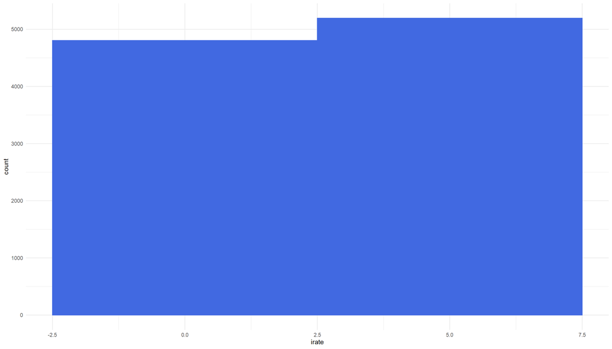

```r
# Create a histogram for irate.
ggplot(df, aes(x = irate)) +
  geom_histogram(binwidth = 5, fill = "royalblue", col = "royalblue")
```

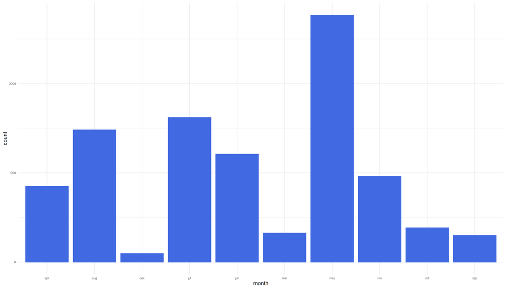

```r
# Create bar chart for month.
ggplot(df, aes(x = month)) +
  geom_bar(stat = "count", fill = "royalblue", col = "royalblue") +
  theme(axis.text = element_text(size = 6))
```

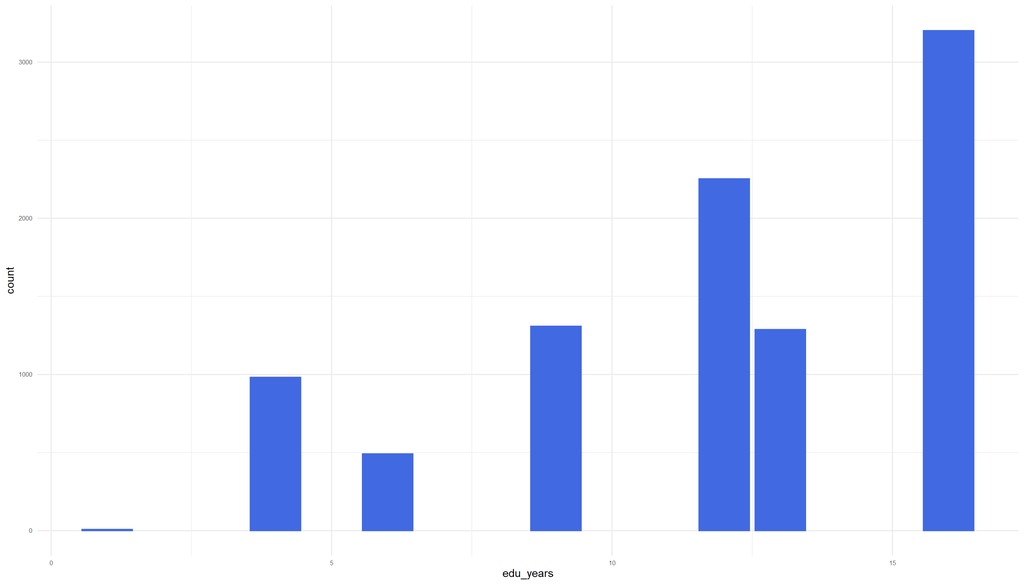

```r
# Create a bar chart for edu_years.
ggplot(df, aes(x = edu_years)) +
  geom_bar(stat = "count", fill = "royalblue", col = "royalblue") +
  theme(axis.text = element_text(size = 6))
```

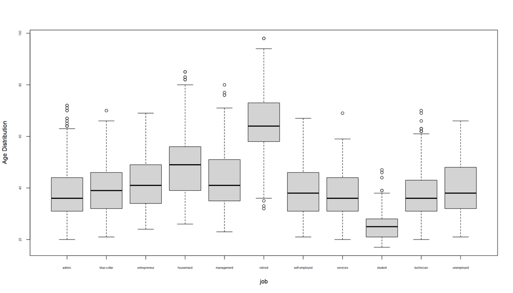

```r
# Create a boxplot of the age distribution for different jobs.
boxplot(age ~ job, data = df, ylab = "Age Distribution", cex.axis = 0.5)
```

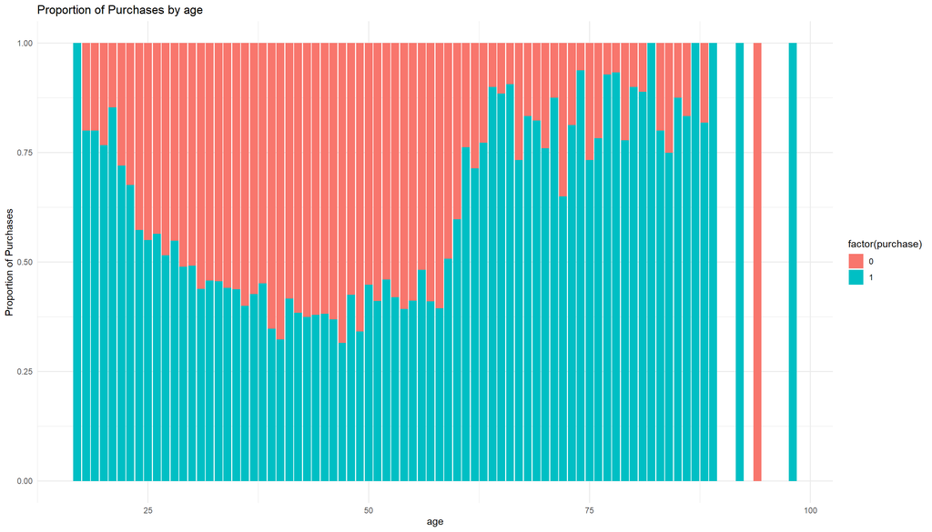

```r
#   Create a graph showing the proportion purchasing by age.
ggplot(df) +
  aes(x = age, fill = factor(purchase)) +
  labs(y = "Proportion of Purchases") +
  ggtitle("Proportion of Purchases by age") +
  geom_bar(position = "fill")
```

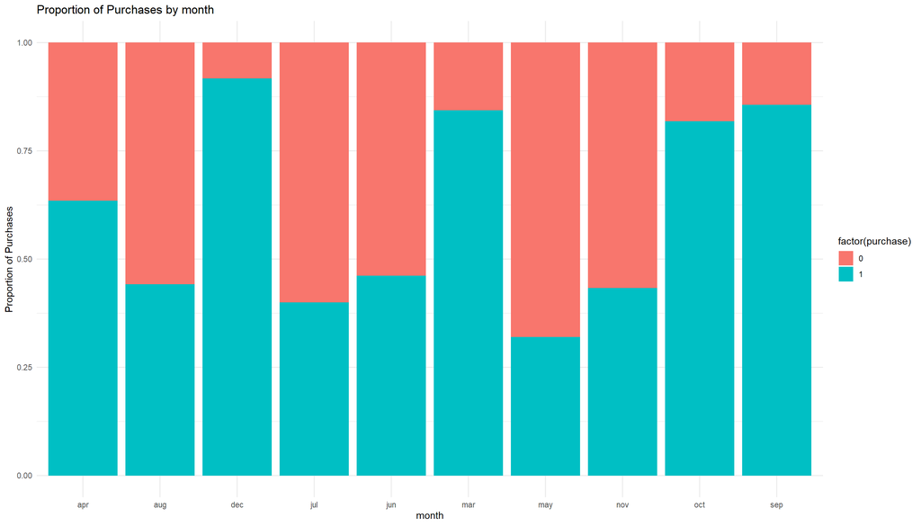

```r
# Create a graph showing the proportion purchasing by month.
ggplot(df) +
  aes(x = month, fill = factor(purchase)) +
  labs(y = "Proportion of Purchases") +
  ggtitle("Proportion of Purchases by month") +
  geom_bar(position = "fill")
```

# Task 2: Consider the education variable.

No code provided.

```r
summary(df)
```

```
##       age            job              marital            housing
##  Min.   :17.00   Length:10000       Length:10000       Length:10000
##  1st Qu.:31.00   Class :character   Class :character   Class :character
##  Median :38.00   Mode  :character   Mode  :character   Mode  :character
##  Mean   :40.42
##  3rd Qu.:48.00
##  Max.   :98.00
##
##      loan              phone              month             weekday
##  Length:10000       Length:10000       Length:10000       Length:10000
##  Class :character   Class :character   Class :character   Class :character
##  Mode  :character   Mode  :character   Mode  :character   Mode  :character
##
##
##
##
##       CPI             CCI             irate         employment
##  Min.   :92.20   Min.   :-50.80   Min.   :0.634   Min.   :4964
##  1st Qu.:92.89   1st Qu.:-42.70   1st Qu.:1.250   1st Qu.:5076
##  Median :93.44   Median :-41.80   Median :4.076   Median :5191
##  Mean   :93.49   Mean   :-40.18   Mean   :3.024   Mean   :5138
##  3rd Qu.:93.99   3rd Qu.:-36.40   3rd Qu.:4.959   3rd Qu.:5228
##  Max.   :94.77   Max.   :-26.90   Max.   :5.045   Max.   :5228
##
##     purchase       edu_years
##  Min.   :0.000   Min.   : 1.00
##  1st Qu.:0.000   1st Qu.: 9.00
##  Median :0.000   Median :12.00
##  Mean   :0.464   Mean   :11.92
##  3rd Qu.:1.000   3rd Qu.:16.00
##  Max.   :1.000   Max.   :16.00
##                  NA's   :466
```

```r
df %>% count(edu_years)
```

```
## # A tibble: 8 x 2
##   edu_years     n
##       <dbl> <int>
## 1         1     8
## 2         4   982
## 3         6   492
## 4         9  1309
## 5        12  2253
## 6        13  1288
## 7        16  3202
## 8        NA   466
```

```r
df %>% count(loan)
```

```
## # A tibble: 3 x 2
##   loan      n
##   <chr> <int>
## 1 no     8270
## 2 yes    1663
## 3 <NA>     67
```

# Task 3: Handle missing values.

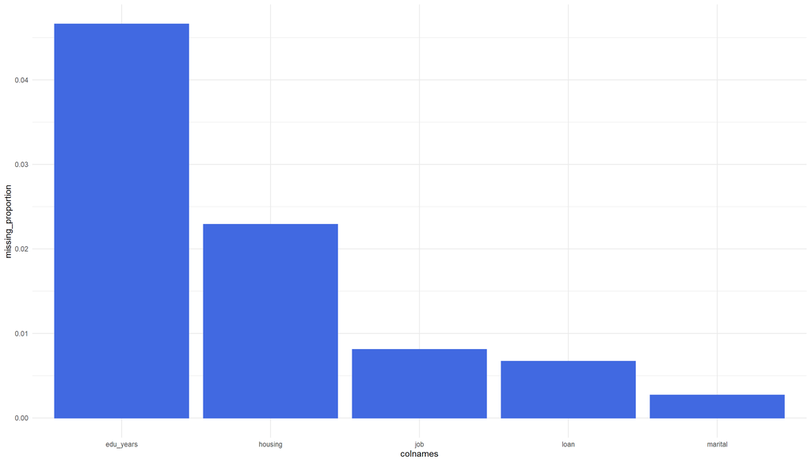

```r
# Check missing values. Display missing proportions for each variable that has them.
missing_proportion <- colMeans(is.na(df))
missing_data <- data.frame(colnames = colnames(df), missing_proportion = missing_proportion)
missing_data %>%
  filter(missing_proportion > 0) %>%
  ggplot(aes(x = colnames, y = missing_proportion, label = missing_proportion)) +
  geom_bar(stat = "identity", fill = "royalblue", col = "royalblue")
```

```r
summary(df)
```

```
##       age            job              marital            housing
##  Min.   :17.00   Length:10000       Length:10000       Length:10000
##  1st Qu.:31.00   Class :character   Class :character   Class :character
##  Median :38.00   Mode  :character   Mode  :character   Mode  :character
##  Mean   :40.42
##  3rd Qu.:48.00
##  Max.   :98.00
##
##      loan              phone              month             weekday
##  Length:10000       Length:10000       Length:10000       Length:10000
##  Class :character   Class :character   Class :character   Class :character
##  Mode  :character   Mode  :character   Mode  :character   Mode  :character
##
##
##
##
##       CPI             CCI             irate         employment
##  Min.   :92.20   Min.   :-50.80   Min.   :0.634   Min.   :4964
##  1st Qu.:92.89   1st Qu.:-42.70   1st Qu.:1.250   1st Qu.:5076
##  Median :93.44   Median :-41.80   Median :4.076   Median :5191
##  Mean   :93.49   Mean   :-40.18   Mean   :3.024   Mean   :5138
##  3rd Qu.:93.99   3rd Qu.:-36.40   3rd Qu.:4.959   3rd Qu.:5228
##  Max.   :94.77   Max.   :-26.90   Max.   :5.045   Max.   :5228
##
##     purchase       edu_years
##  Min.   :0.000   Min.   : 1.00
##  1st Qu.:0.000   1st Qu.: 9.00
##  Median :0.000   Median :12.00
##  Mean   :0.464   Mean   :11.92
##  3rd Qu.:1.000   3rd Qu.:16.00
##  Max.   :1.000   Max.   :16.00
##                  NA's   :466
```

```r
# The code below calculates the proportion of purchases for NAs and for nonNAs for each variable that has NAs.
#
print("Purchase Proportions by variable, for missing and non missing values")
```

```
## [1] "Purchase Proportions by variable, for missing and non missing values"
```

```r
print(sprintf("%10s %15s %15s", "Variable", "PP_for_NAs", "PP_for_non_NAs"))
```

```
## [1] "  Variable      PP_for_NAs  PP_for_non_NAs"
```

```r
varnames <- c("housing", "job", "loan", "marital", "edu_years")
for (t in varnames)
{
  ind <- is.na(df[t])
  print(sprintf("%10s %15.2f %15.2f", t, mean(df["purchase"][ind]), mean(df["purchase"][!ind])))
}
```

```
## [1] "   housing            0.47            0.46"
## [1] "       job            0.46            0.46"
## [1] "      loan            0.52            0.46"
## [1] "   marital            0.44            0.46"
## [1] " edu_years            0.54            0.46"
```

```r
#edu_years

# Impute using the mean (works only for numeric variables)
df$edu_years[is.na(df$edu_years)] <- mean(df$edu_years, na.rm = TRUE)
summary(df)
```

```
##       age            job              marital            housing
##  Min.   :17.00   Length:10000       Length:10000       Length:10000
##  1st Qu.:31.00   Class :character   Class :character   Class :character
##  Median :38.00   Mode  :character   Mode  :character   Mode  :character
##  Mean   :40.42
##  3rd Qu.:48.00
##  Max.   :98.00
##      loan              phone              month             weekday
##  Length:10000       Length:10000       Length:10000       Length:10000
##  Class :character   Class :character   Class :character   Class :character
##  Mode  :character   Mode  :character   Mode  :character   Mode  :character
##
##
##
##       CPI             CCI             irate         employment
##  Min.   :92.20   Min.   :-50.80   Min.   :0.634   Min.   :4964
##  1st Qu.:92.89   1st Qu.:-42.70   1st Qu.:1.250   1st Qu.:5076
##  Median :93.44   Median :-41.80   Median :4.076   Median :5191
##  Mean   :93.49   Mean   :-40.18   Mean   :3.024   Mean   :5138
##  3rd Qu.:93.99   3rd Qu.:-36.40   3rd Qu.:4.959   3rd Qu.:5228
##  Max.   :94.77   Max.   :-26.90   Max.   :5.045   Max.   :5228
##     purchase       edu_years
##  Min.   :0.000   Min.   : 1.00
##  1st Qu.:0.000   1st Qu.: 9.00
##  Median :0.000   Median :12.00
##  Mean   :0.464   Mean   :11.92
##  3rd Qu.:1.000   3rd Qu.:16.00
##  Max.   :1.000   Max.   :16.00
```

```r
df %>% count(job)
```

```
## # A tibble: 12 x 2
##    job               n
##    <chr>         <int>
##  1 admin.         2691
##  2 blue-collar    1919
##  3 entrepreneur    298
##  4 housemaid       247
##  5 management      708
##  6 retired         645
##  7 self-employed   332
##  8 services        832
##  9 student         376
## 10 technician     1603
## 11 unemployed      268
## 12 <NA>             81
```

```r
df %>% count(marital)
```

```
## # A tibble: 4 x 2
##   marital      n
##   <chr>    <int>
## 1 divorced  1087
## 2 married   5843
## 3 single    3043
## 4 <NA>        27
```

```r
summary(df)
```

```
##       age            job              marital            housing
##  Min.   :17.00   Length:10000       Length:10000       Length:10000
##  1st Qu.:31.00   Class :character   Class :character   Class :character
##  Median :38.00   Mode  :character   Mode  :character   Mode  :character
##  Mean   :40.42
##  3rd Qu.:48.00
##  Max.   :98.00
##      loan              phone              month             weekday
##  Length:10000       Length:10000       Length:10000       Length:10000
##  Class :character   Class :character   Class :character   Class :character
##  Mode  :character   Mode  :character   Mode  :character   Mode  :character
##
##
##
##       CPI             CCI             irate         employment
##  Min.   :92.20   Min.   :-50.80   Min.   :0.634   Min.   :4964
##  1st Qu.:92.89   1st Qu.:-42.70   1st Qu.:1.250   1st Qu.:5076
##  Median :93.44   Median :-41.80   Median :4.076   Median :5191
##  Mean   :93.49   Mean   :-40.18   Mean   :3.024   Mean   :5138
##  3rd Qu.:93.99   3rd Qu.:-36.40   3rd Qu.:4.959   3rd Qu.:5228
##  Max.   :94.77   Max.   :-26.90   Max.   :5.045   Max.   :5228
##     purchase       edu_years
##  Min.   :0.000   Min.   : 1.00
##  1st Qu.:0.000   1st Qu.: 9.00
##  Median :0.000   Median :12.00
##  Mean   :0.464   Mean   :11.92
##  3rd Qu.:1.000   3rd Qu.:16.00
##  Max.   :1.000   Max.   :16.00
```

```r
#housing
# Remove rows
df <- df[!is.na(df$housing), ]

#job
# Convert missing values to "unknown" (works only for factor variables)

# First create a new level.
levels(df$job)[length(levels(df$job)) + 1] <- "missing"
# Then use the new level to indicate NA.
df$varname[is.na(df$job)] <- "missing"

df <- df %>% mutate(job = ifelse(is.na(job), yes = "Missing", no = job))

#marital
# Remove rows
df <- df[!is.na(df$marital), ]

sum(is.na(df))
```

```
## [1] 9667
```

```r
summary(df)
```

```
##       age            job              marital            housing
##  Min.   :17.00   Length:9744        Length:9744        Length:9744
##  1st Qu.:31.00   Class :character   Class :character   Class :character
##  Median :38.00   Mode  :character   Mode  :character   Mode  :character
##  Mean   :40.41
##  3rd Qu.:48.00
##  Max.   :98.00
##      loan              phone              month             weekday
##  Length:9744        Length:9744        Length:9744        Length:9744
##  Class :character   Class :character   Class :character   Class :character
##  Mode  :character   Mode  :character   Mode  :character   Mode  :character
##
##
##
##       CPI             CCI            irate         employment      purchase
##  Min.   :92.20   Min.   :-50.8   Min.   :0.634   Min.   :4964   Min.   :0.000
##  1st Qu.:92.89   1st Qu.:-42.7   1st Qu.:1.250   1st Qu.:5076   1st Qu.:0.000
##  Median :93.44   Median :-41.8   Median :4.076   Median :5191   Median :0.000
##  Mean   :93.49   Mean   :-40.2   Mean   :3.027   Mean   :5138   Mean   :0.464
##  3rd Qu.:93.99   3rd Qu.:-36.4   3rd Qu.:4.959   3rd Qu.:5228   3rd Qu.:1.000
##  Max.   :94.77   Max.   :-26.9   Max.   :5.045   Max.   :5228   Max.   :1.000
##    edu_years       varname
##  Min.   : 1.00   Length:9744
##  1st Qu.: 9.00   Class :character
##  Median :12.00   Mode  :character
##  Mean   :11.93
##  3rd Qu.:16.00
##  Max.   :16.00
```

```r
df %>% mutate_if(is.character,as.factor) %>% summary()
```

```
##       age                 job           marital     housing     loan
##  Min.   :17.00   admin.     :2624   divorced:1061   no :4435   no :8214
##  1st Qu.:31.00   blue-collar:1870   married :5721   yes:5309   yes:1530
##  Median :38.00   technician :1558   single  :2962
##  Mean   :40.41   services   : 812
##  3rd Qu.:48.00   management : 693
##  Max.   :98.00   retired    : 623
##                  (Other)    :1564
##       phone          month      weekday         CPI             CCI
##  cellular:6977   may    :2696   fri:1789   Min.   :92.20   Min.   :-50.8
##  landline:2767   jul    :1593   mon:1934   1st Qu.:92.89   1st Qu.:-42.7
##                  aug    :1442   thu:2093   Median :93.44   Median :-41.8
##                  jun    :1173   tue:1944   Mean   :93.49   Mean   :-40.2
##                  nov    : 939   wed:1984   3rd Qu.:93.99   3rd Qu.:-36.4
##                  apr    : 827              Max.   :94.77   Max.   :-26.9
##                  (Other):1074
##      irate         employment      purchase       edu_years        varname
##  Min.   :0.634   Min.   :4964   Min.   :0.000   Min.   : 1.00   missing:  77
##  1st Qu.:1.250   1st Qu.:5076   1st Qu.:0.000   1st Qu.: 9.00   NA's   :9667
##  Median :4.076   Median :5191   Median :0.000   Median :12.00
##  Mean   :3.027   Mean   :5138   Mean   :0.464   Mean   :11.93
##  3rd Qu.:4.959   3rd Qu.:5228   3rd Qu.:1.000   3rd Qu.:16.00
##  Max.   :5.045   Max.   :5228   Max.   :1.000   Max.   :16.00
##
```

```r
df$varname <- NULL
```

```r
df %>%
  mutate(edu_years = ifelse(is.na(edu_years), mean(df$edu_years), edu_years),
         job = ifelse(is.na(job), "missing", job)) %>%
  filter(!is.na(housing),
         !is.na(marital)) %>%
  summary()
```

[output not shown]

The following code can be used to handle missing values.

```r
# Use one of the four choices below to deal with the NAs.
# Choose for each variable that has NAs.
# Replace varname with the actual variable name.

# Remove column
df$varname <- NULL

# Remove rows
df <- df[!is.na(df$varname), ]

# Convert missing values to "unknown" (works only for factor variables)
# First create a new level.
levels(df$varname)[length(levels(df$varname)) + 1] <- "unknown"
# Then use the new level to indicate NA.
df$varname[is.na(df$varname)] <- "unknown"

# Impute using the mean (works only for numeric variables)
df$varname[is.na(df$varname)] <- mean(df$varname, na.rm = TRUE)
```

# Task 4: Investigate correlations.

```r
tmp <- dplyr::select(df, age, edu_years, CPI, CCI, irate, employment)
cor(tmp, use = "complete.obs")
```

```
##                    age   edu_years         CPI         CCI       irate
## age         1.00000000 -0.23774026 -0.01560317  0.14346272 -0.04699884
## edu_years  -0.23774026  1.00000000 -0.09428042  0.03840496 -0.08576398
## CPI        -0.01560317 -0.09428042  1.00000000 -0.14981433  0.57719297
## CCI         0.14346272  0.03840496 -0.14981433  1.00000000  0.05798463
## irate      -0.04699884 -0.08576398  0.57719297  0.05798463  1.00000000
## employment -0.07896364 -0.08277156  0.35762684 -0.07419180  0.94142899
##             employment
## age        -0.07896364
## edu_years  -0.08277156
## CPI         0.35762684
## CCI        -0.07419180
## irate       0.94142899
## employment  1.00000000
```

# Task 5: Conduct a principal components analysis (PCA)

```r
# Perform Principal Components Analysis of the four variables below.
# The variables are standardized. Then the components are calculated.
tmp <- dplyr::select(df, CPI, CCI, irate, employment)
apply(tmp, 2, mean)
```

```
##         CPI         CCI       irate  employment
##   93.485500  -40.195515    3.026502 5138.323635
```

```r
apply(tmp, 2, sd)
```

```
##        CPI        CCI      irate employment
##  0.6272815  5.3100569  1.8867636 86.2665799
```

```r
pca <- prcomp(tmp, scale = TRUE)
pca
```

```
## Standard deviations (1, .., p=4):
## [1] 1.5129556 1.0201639 0.8118269 0.1056792
##
## Rotation (n x k) = (4 x 4):
##                    PC1         PC2        PC3        PC4
## CPI        -0.46359100  0.24017641  0.8239862  0.2201031
## CCI         0.05957596 -0.95082958  0.2776338  0.1236661
## irate      -0.64581167 -0.17032638 -0.1173823 -0.7349406
## employment -0.60370637 -0.09605903 -0.4797787  0.6293836
```

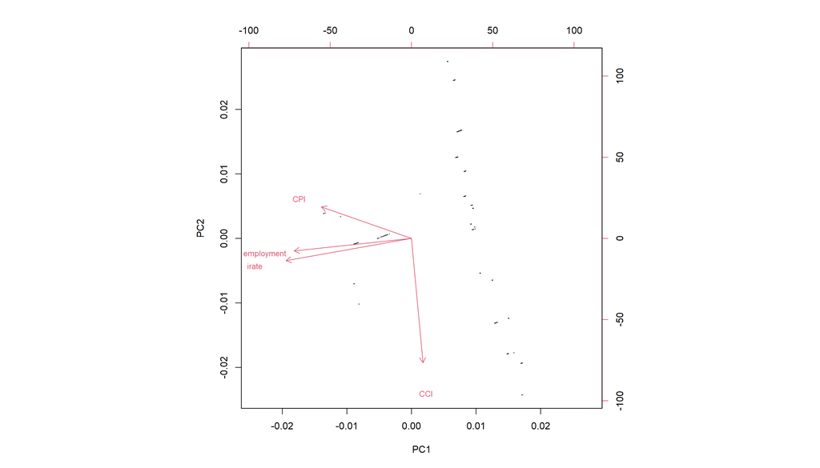

```r
#   Create a bi-plot.
biplot(pca, cex = 0.8, xlabs = rep(".", nrow(tmp)))
```

```r
# Consider the variance explained by the principal components.
# Use the output to decide how many principal components to use in the GLM models.
vars_pca <- apply(pca$x, 2, var)
vars_pca / sum(vars_pca)
```

```
##         PC1         PC2         PC3         PC4
## 0.572258677 0.260183578 0.164765721 0.002792024
```

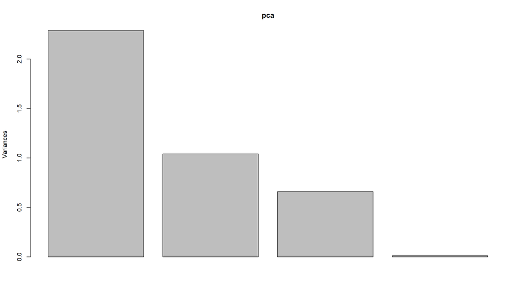

```r
plot(pca)
```

Calculate the principal components and add the first one to the data frame.

```r
pred <- as.data.frame(predict(pca, newdata = df[, c("CPI", "CCI", "irate", "employment")]))

df$PC1 <- pred$PC1
```

Split the data into training and testing. Check that the split looks reasonable.

```r
set.seed(1875)
train_ind <- createDataPartition(df$purchase, p = 0.7, list = FALSE)
data_train <- df[train_ind, ]
data_test <- df[-train_ind, ]
rm(train_ind)

print("Mean value of purchase on train and test data splits")
```

```
## [1] "Mean value of purchase on train and test data splits"
```

```r
mean(data_train$purchase)
```

```
## [1] 0.4656209
```

```r
mean(data_test$purchase)
```

```
## [1] 0.4601437
```

```r
summary(df)
```

```
##       age            job              marital            housing
##  Min.   :17.00   Length:9744        Length:9744        Length:9744
##  1st Qu.:31.00   Class :character   Class :character   Class :character
##  Median :38.00   Mode  :character   Mode  :character   Mode  :character
##  Mean   :40.41
##  3rd Qu.:48.00
##  Max.   :98.00
##      loan              phone              month             weekday
##  Length:9744        Length:9744        Length:9744        Length:9744
##  Class :character   Class :character   Class :character   Class :character
##  Mode  :character   Mode  :character   Mode  :character   Mode  :character
##
##
##
##       CPI             CCI            irate         employment      purchase
##  Min.   :92.20   Min.   :-50.8   Min.   :0.634   Min.   :4964   Min.   :0.000
##  1st Qu.:92.89   1st Qu.:-42.7   1st Qu.:1.250   1st Qu.:5076   1st Qu.:0.000
##  Median :93.44   Median :-41.8   Median :4.076   Median :5191   Median :0.000
##  Mean   :93.49   Mean   :-40.2   Mean   :3.027   Mean   :5138   Mean   :0.464
##  3rd Qu.:93.99   3rd Qu.:-36.4   3rd Qu.:4.959   3rd Qu.:5228   3rd Qu.:1.000
##  Max.   :94.77   Max.   :-26.9   Max.   :5.045   Max.   :5228   Max.   :1.000
##    edu_years          PC1
##  Min.   : 1.00   Min.   :-2.0344
##  1st Qu.: 9.00   1st Qu.:-1.3291
##  Median :12.00   Median :-0.5707
##  Mean   :11.93   Mean   : 0.0000
##  3rd Qu.:16.00   3rd Qu.: 1.2510
##  Max.   :16.00   Max.   : 2.5635
```

# Task 6: Create a generalized linear model (GLM).

> Don’t panic. You’ll notice that the coefficients in this Rmd file are different that what is in the report. You can expect this to happen to you and plan ahead. It would a perfect if both matched 100% of the time, but in inevitably you will encounter these types of discrepencies. Sometimes this is due to the random seed being different and different observations being used in the training and test sets. It may also be due to differences in how the data was handled. Perhaps the model was run on an earlier version of the data, and then I went back and made a change but did not update the values in the document. **If you notice this, leave a comment such as this one in your Rmd file so that you’ll still get full credit.**

```r
# Construct GLM using only age as an independent variable.

glm <- glm(purchase ~ age,
  data = data_train,
  family = binomial(link = "logit")
)

summary(glm)
```

```
##
## Call:
## glm(formula = purchase ~ age, family = binomial(link = "logit"),
##     data = data_train)
##
## Deviance Residuals:
##    Min      1Q  Median      3Q     Max
## -1.259  -1.116  -1.086   1.243   1.299
##
## Coefficients:
##              Estimate Std. Error z value Pr(>|z|)
## (Intercept) -0.385209   0.085560  -4.502 6.72e-06 ***
## age          0.006122   0.002028   3.018  0.00254 **
## ---
## Signif. codes:  0 '***' 0.001 '**' 0.01 '*' 0.05 '.' 0.1 ' ' 1
##
## (Dispersion parameter for binomial family taken to be 1)
##
##     Null deviance: 9423.6  on 6820  degrees of freedom
## Residual deviance: 9414.5  on 6819  degrees of freedom
## AIC: 9418.5
##
## Number of Fisher Scoring iterations: 3
```

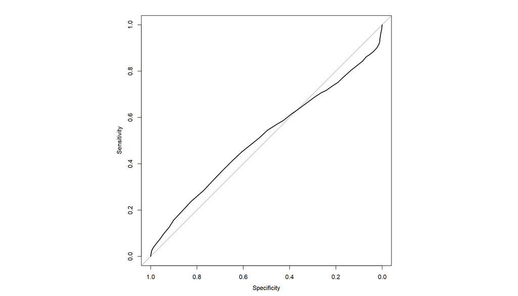

```r
# Evaluate GLM: construct ROC and calculate AUC
library(pROC)

glm_probs <- predict(glm, data_train, type = "response")
glm_probs_test <- predict(glm, data_test, type = "response")

roc <- roc(data_train$purchase, glm_probs)
par(pty = "s")
plot(roc)
```

```r
pROC::auc(roc)
```

```
## Area under the curve: 0.5114
```

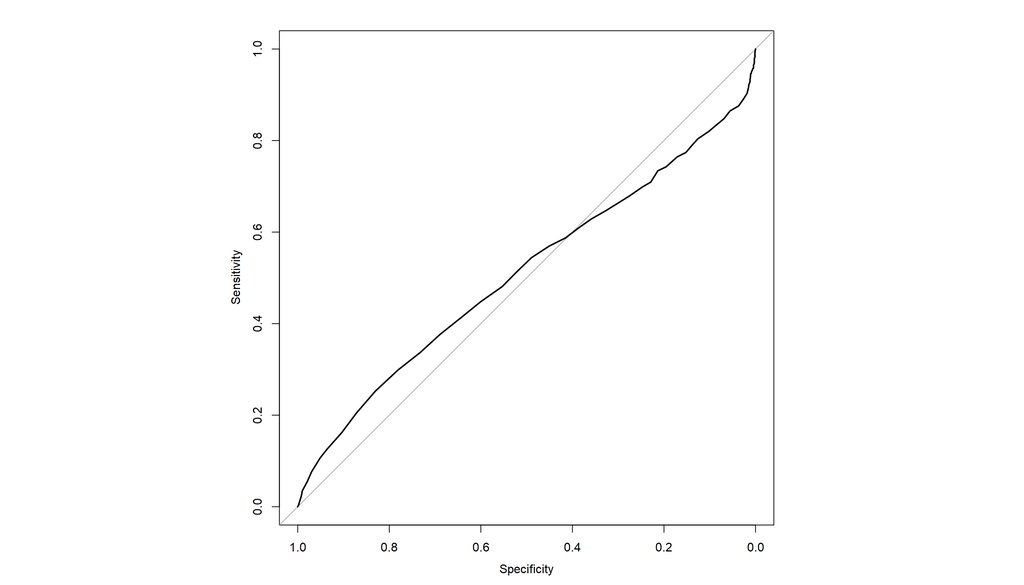

```r
roc <- roc(data_test$purchase, glm_probs_test)
plot(roc)
```

```r
pROC::auc(roc)
```

```
## Area under the curve: 0.5101
```

```r
# Construct a GLM using a full set of independent variables and the first PC.

glm <- glm(purchase ~ age + job + marital + edu_years + housing + loan + phone + month + weekday + PC1,
  data = data_train,
  family = binomial(link = "logit")
)

summary(glm)
```

```
##
## Call:
## glm(formula = purchase ~ age + job + marital + edu_years + housing +
##     loan + phone + month + weekday + PC1, family = binomial(link = "logit"),
##     data = data_train)
##
## Deviance Residuals:
##     Min       1Q   Median       3Q      Max
## -2.4432  -0.8613  -0.5490   0.8897   2.1453
##
## Coefficients:
##                   Estimate Std. Error z value Pr(>|z|)
## (Intercept)      -0.450359   0.254617  -1.769  0.07693 .
## age               0.001638   0.003349   0.489  0.62467
## jobblue-collar   -0.145314   0.100376  -1.448  0.14770
## jobentrepreneur  -0.172836   0.171210  -1.009  0.31274
## jobhousemaid     -0.080472   0.201927  -0.399  0.69025
## jobmanagement    -0.010063   0.116801  -0.086  0.93134
## jobMissing        0.066541   0.333064   0.200  0.84165
## jobretired        0.267047   0.155195   1.721  0.08530 .
## jobself-employed -0.005757   0.161045  -0.036  0.97148
## jobservices      -0.031189   0.111855  -0.279  0.78037
## jobstudent        0.306132   0.171980   1.780  0.07507 .
## jobtechnician    -0.045558   0.087957  -0.518  0.60449
## jobunemployed     0.060734   0.180691   0.336  0.73678
## maritalmarried   -0.019008   0.092061  -0.206  0.83642
## maritalsingle     0.070750   0.106062   0.667  0.50473
## edu_years         0.013512   0.009678   1.396  0.16268
## housingyes       -0.044145   0.056473  -0.782  0.43439
## loanyes          -0.095973   0.077625  -1.236  0.21632
## phonelandline    -0.057336   0.086440  -0.663  0.50714
## monthaug          0.105057   0.120123   0.875  0.38180
## monthdec          1.436008   0.526566   2.727  0.00639 **
## monthjul          0.494028   0.124721   3.961 7.46e-05 ***
## monthjun          0.640455   0.129558   4.943 7.68e-07 ***
## monthmar          0.948278   0.207531   4.569 4.89e-06 ***
## monthmay         -0.540666   0.103828  -5.207 1.92e-07 ***
## monthnov         -0.103093   0.125204  -0.823  0.41028
## monthoct          1.076100   0.204118   5.272 1.35e-07 ***
## monthsep          0.926083   0.232875   3.977 6.99e-05 ***
## weekdaymon       -0.188074   0.090939  -2.068  0.03863 *
## weekdaythu        0.144222   0.088597   1.628  0.10356
## weekdaytue        0.029631   0.090899   0.326  0.74444
## weekdaywed        0.159714   0.090444   1.766  0.07742 .
## PC1               0.636283   0.027805  22.884  < 2e-16 ***
## ---
## Signif. codes:  0 '***' 0.001 '**' 0.01 '*' 0.05 '.' 0.1 ' ' 1
##
## (Dispersion parameter for binomial family taken to be 1)
##
##     Null deviance: 9423.6  on 6820  degrees of freedom
## Residual deviance: 7650.3  on 6788  degrees of freedom
## AIC: 7716.3
##
## Number of Fisher Scoring iterations: 5
```

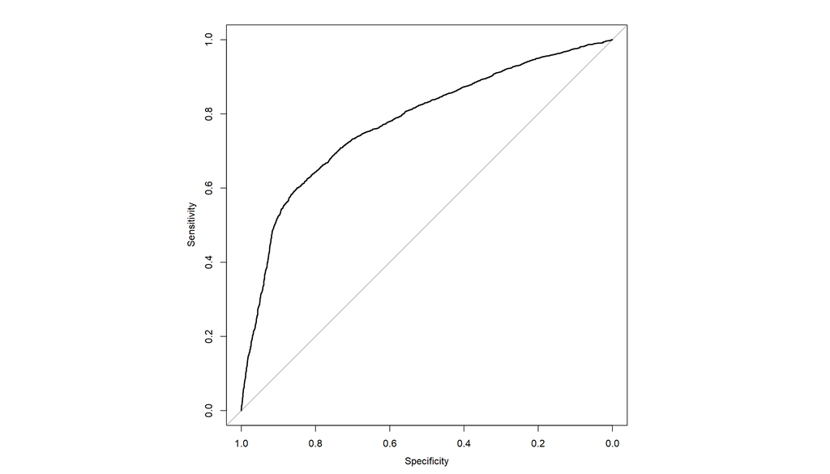

```r
# Evaluate GLM: construct ROC and calculate AUC

glm_probs <- predict(glm, data_train, type = "response")
glm_probs_test <- predict(glm, data_test, type = "response")

roc <- roc(data_train$purchase, glm_probs)
par(pty = "s")
plot(roc)
```

```r
pROC::auc(roc)
```

```
## Area under the curve: 0.7765
```

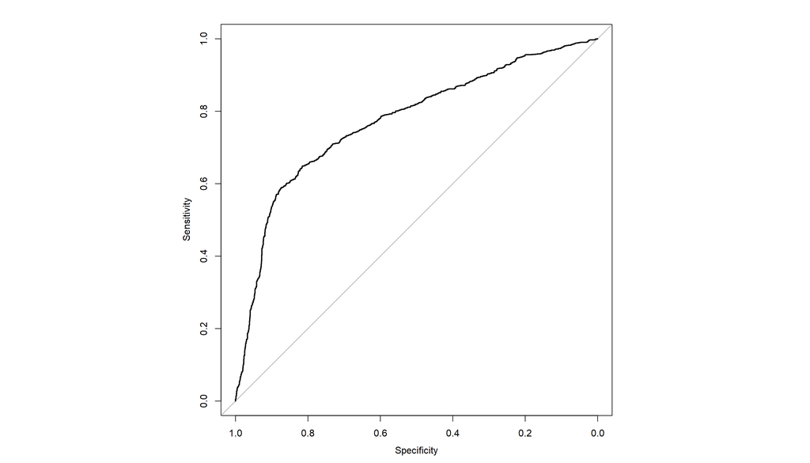

```r
roc <- roc(data_test$purchase, glm_probs_test)
plot(roc)
```

```r
pROC::auc(roc)
```

```
## Area under the curve: 0.773
```

# Task 7: Select features using stepwise selection.

```r
# The following code executes the stepAIC procedure with backward selection and AIC. It first runs a new GLM adding the square of age.

glm2 <- glm(purchase ~ age + I(age^2) + job + marital + edu_years + housing + loan + phone + month + weekday + PC1,
  data = data_train,
  family = binomial(link = "logit")
)

library(MASS)


stepAIC(glm2,
  direction = "backward",
  k = 2
)
```

```
## Start:  AIC=7711.11
## purchase ~ age + I(age^2) + job + marital + edu_years + housing +
##     loan + phone + month + weekday + PC1
##
##             Df Deviance    AIC
## - job       11   7649.3 7695.3
## - marital    2   7643.7 7707.7
## - phone      1   7643.7 7709.7
## - housing    1   7643.7 7709.7
## - loan       1   7644.7 7710.7
## <none>           7643.1 7711.1
## - edu_years  1   7645.6 7711.6
## - age        1   7649.5 7715.5
## - I(age^2)   1   7650.3 7716.3
## - weekday    4   7662.8 7722.8
## - month      9   7936.4 7986.4
## - PC1        1   8197.6 8263.6
##
## Step:  AIC=7695.27
## purchase ~ age + I(age^2) + marital + edu_years + housing + loan +
##     phone + month + weekday + PC1
##
##             Df Deviance    AIC
## - marital    2   7650.4 7692.4
## - phone      1   7649.7 7693.7
## - housing    1   7649.9 7693.9
## - loan       1   7650.7 7694.7
## <none>           7649.3 7695.3
## - edu_years  1   7656.7 7700.7
## - age        1   7661.5 7705.5
## - weekday    4   7668.8 7706.8
## - I(age^2)   1   7664.2 7708.2
## - month      9   7951.6 7979.6
## - PC1        1   8226.4 8270.4
##
## Step:  AIC=7692.35
## purchase ~ age + I(age^2) + edu_years + housing + loan + phone +
##     month + weekday + PC1
##
##             Df Deviance    AIC
```

[output cut: 36 more lines]

```
## - I(age^2)   1   7669.1 7705.1
## - month      9   7965.5 7985.5
## - PC1        1   8477.5 8513.5
##
## Step:  AIC=7688.82
## purchase ~ age + I(age^2) + edu_years + month + weekday + PC1
##
##             Df Deviance    AIC
## <none>           7652.8 7688.8
## - edu_years  1   7660.9 7694.9
## - weekday    4   7672.1 7700.1
## - age        1   7668.8 7702.8
## - I(age^2)   1   7670.5 7704.5
## - month      9   7967.0 7985.0
## - PC1        1   8479.5 8513.5
```

```
##
## Call:  glm(formula = purchase ~ age + I(age^2) + edu_years + month +
##     weekday + PC1, family = binomial(link = "logit"), data = data_train)
##
## Coefficients:
## (Intercept)          age     I(age^2)    edu_years     monthaug     monthdec
##   0.6136436   -0.0580619    0.0006706    0.0221466    0.1346618    1.4173934
##    monthjul     monthjun     monthmar     monthmay     monthnov     monthoct
##   0.5043561    0.6290797    0.9371586   -0.5471590   -0.0951704    1.0759523
##    monthsep   weekdaymon   weekdaythu   weekdaytue   weekdaywed          PC1
##   0.9151836   -0.1874572    0.1366409    0.0230683    0.1505281    0.6411362
##
## Degrees of Freedom: 6820 Total (i.e. Null);  6803 Residual
## Null Deviance:       9424
## Residual Deviance: 7653  AIC: 7689
```

```r
sum(is.na(data_train))
```

```
## [1] 0
```

```r
# To evaluate the selected model, change the variable list to those selected by stepAIC.
glm.reduced <- glm(purchase ~ age + I(age^2) + edu_years + month +
    weekday + PC1,
  data = data_train,
  family = binomial(link = "logit")
)

summary(glm.reduced)
```

```
##
## Call:
## glm(formula = purchase ~ age + I(age^2) + edu_years + month +
##     weekday + PC1, family = binomial(link = "logit"), data = data_train)
##
## Deviance Residuals:
##     Min       1Q   Median       3Q      Max
## -2.6222  -0.8637  -0.5569   0.9003   2.1208
##
## Coefficients:
##               Estimate Std. Error z value Pr(>|z|)
## (Intercept)  0.6136436  0.3493331   1.757 0.078984 .
## age         -0.0580619  0.0149631  -3.880 0.000104 ***
## I(age^2)     0.0006706  0.0001664   4.029 5.61e-05 ***
## edu_years    0.0221466  0.0077813   2.846 0.004425 **
## monthaug     0.1346618  0.1170023   1.151 0.249760
## monthdec     1.4173934  0.5260318   2.695 0.007049 **
## monthjul     0.5043561  0.1215486   4.149 3.33e-05 ***
## monthjun     0.6290797  0.1269090   4.957 7.16e-07 ***
## monthmar     0.9371586  0.2074449   4.518 6.25e-06 ***
## monthmay    -0.5471590  0.1025871  -5.334 9.63e-08 ***
## monthnov    -0.0951704  0.1242596  -0.766 0.443736
## monthoct     1.0759523  0.2028526   5.304 1.13e-07 ***
## monthsep     0.9151836  0.2323805   3.938 8.21e-05 ***
## weekdaymon  -0.1874572  0.0907742  -2.065 0.038914 *
## weekdaythu   0.1366409  0.0883776   1.546 0.122080
## weekdaytue   0.0230683  0.0908747   0.254 0.799613
## weekdaywed   0.1505281  0.0902466   1.668 0.095323 .
## PC1          0.6411362  0.0239317  26.790  < 2e-16 ***
## ---
## Signif. codes:  0 '***' 0.001 '**' 0.01 '*' 0.05 '.' 0.1 ' ' 1
##
## (Dispersion parameter for binomial family taken to be 1)
##
##     Null deviance: 9423.6  on 6820  degrees of freedom
## Residual deviance: 7652.8  on 6803  degrees of freedom
## AIC: 7688.8
##
## Number of Fisher Scoring iterations: 5
```

# Task 8: Evaluate the model.

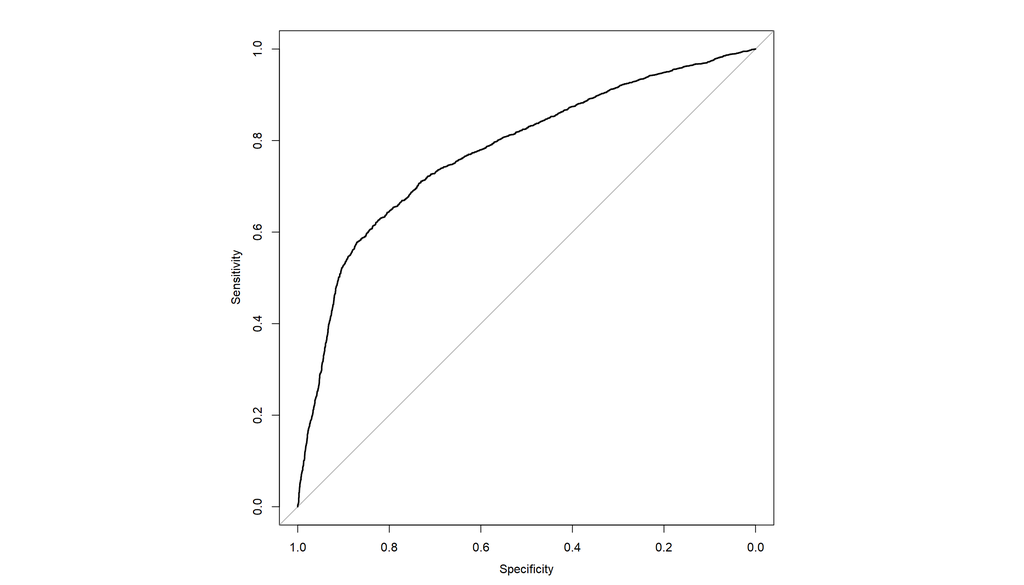

```r
# Evaluate GLM: construct ROC and calculate AUC

glm_probs <- predict(glm.reduced, data_train, type = "response")
glm_probs_test <- predict(glm.reduced, data_test, type = "response")

roc <- roc(data_train$purchase, glm_probs)
par(pty = "s")
plot(roc)
```

```r
pROC::auc(roc)
```

```
## Area under the curve: 0.7766
```

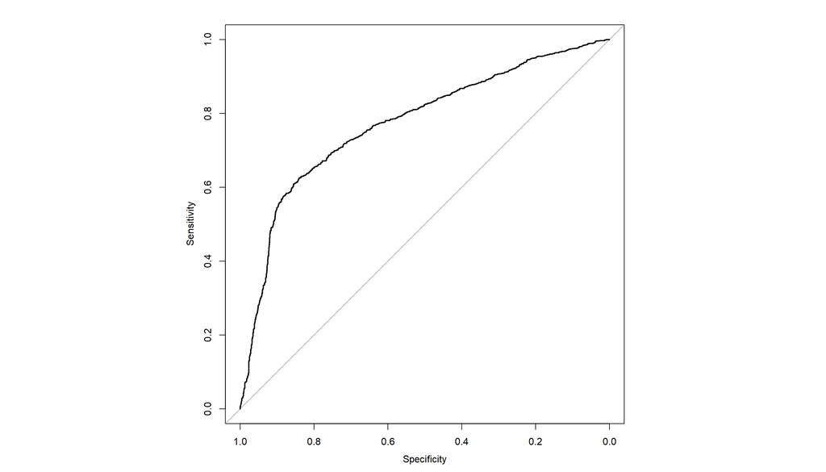

```r
roc <- roc(data_test$purchase, glm_probs_test)
plot(roc)
```

```r
pROC::auc(roc)
```

```
## Area under the curve: 0.7735
```

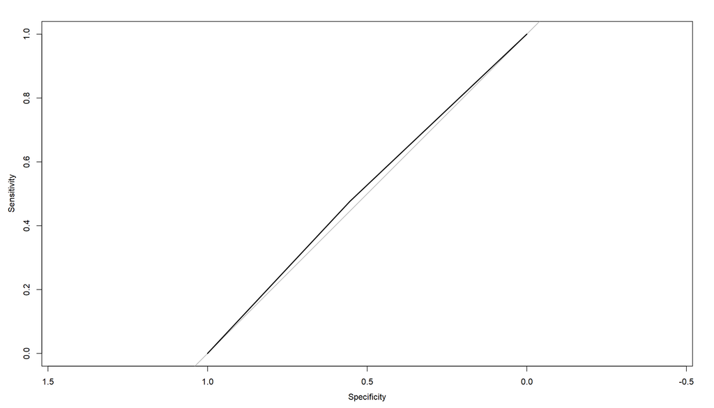

```r
#Example: AUC = 0.5
#Randomly choose customers as 0 or 1 in the same proportion as the actual data
random_permutation <- sample(data_test$purchase, size = length(data_test$purchase), replace = F)
roc <- roc(data_test$purchase, random_permutation)
plot(roc)
```

```r
pROC::auc(roc)
```

```
## Area under the curve: 0.5152
```

Example of AUC of 1

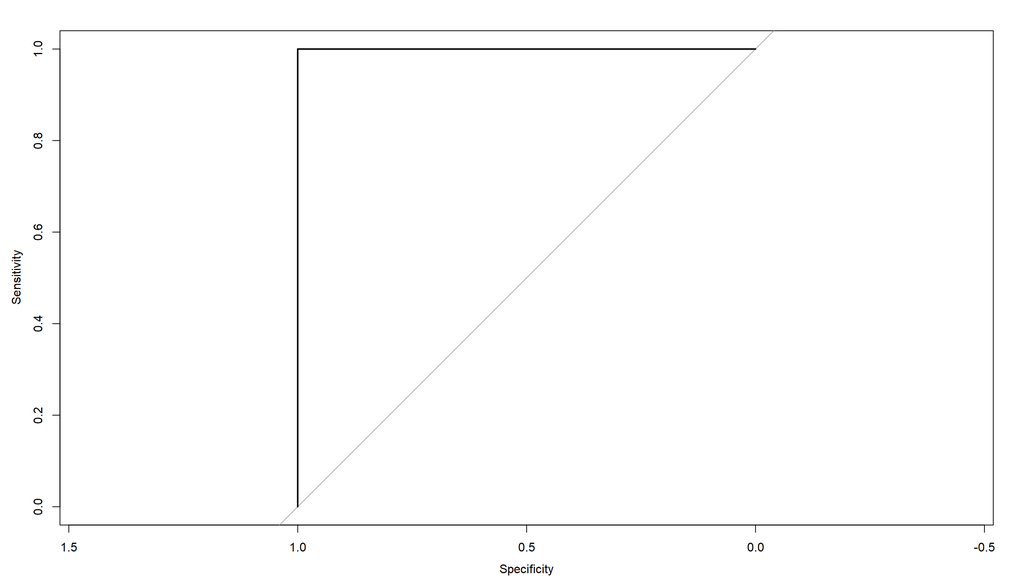

```r
glm_probs_test <- data_test$purchase

roc <- roc(data_test$purchase, glm_probs_test)
plot(roc)
```

```r
pROC::auc(roc)
```

```
## Area under the curve: 1
```

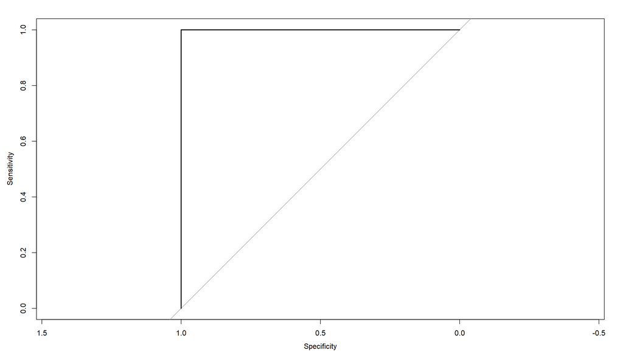

```r
glm_probs_test <-  data_test$purchase

roc <- roc(data_test$purchase, glm_probs_test)
plot(roc)
```

```r
pROC::auc(roc)
```

```
## Area under the curve: 1
```

Check the base levels

```r
levels(as.factor(data_train$month))
```

```
##  [1] "apr" "aug" "dec" "jul" "jun" "mar" "may" "nov" "oct" "sep"
```

```r
levels(as.factor(data_train$weekday))
```

```
## [1] "fri" "mon" "thu" "tue" "wed"
```

# Task 9: Investigate a shrinkage method.

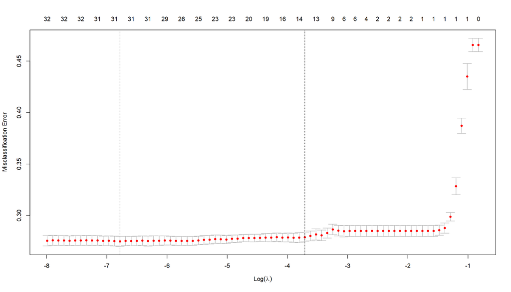

```r
library(glmnet)
set.seed(42)


X.train <- model.matrix(purchase ~ age + I(age^2) + job + marital + edu_years + housing + loan + phone + month + weekday + PC1,
  data = data_train
)
X.test <- model.matrix(purchase ~ age + I(age^2) + job + marital + edu_years + housing + loan + phone + month + weekday + PC1,
  data = data_test
)

m <- cv.glmnet(
  x = X.train,
  y = data_train$purchase,
  family = "binomial",
  type.measure = "class",
  alpha = 0.5
) # alpha = 1 implies LASSO, alpha = 0 implies ridge, values between 0 and 1 imply elastic net
plot(m)
```

Use the cross-validation results to run the final elastic net regression model.

```r
# Fit the model
m.final <- glmnet(
  x = X.train,
  y = data_train$purchase,
  family = "binomial",
  lambda = m$lambda.min,
  alpha = 0.5
)

# List variables
m.final$beta
```

```
## 34 x 1 sparse Matrix of class "dgCMatrix"
##                             s0
## (Intercept)       .
## age              -0.0128135680
## I(age^2)          0.0001716616
## jobblue-collar   -0.1334484063
## jobentrepreneur  -0.1530309853
## jobhousemaid     -0.0627748536
## jobmanagement     .
## jobMissing        0.0231390473
## jobretired        0.1864601755
## jobself-employed  .
## jobservices      -0.0175040228
## jobstudent        0.2749409922
## jobtechnician    -0.0297073360
## jobunemployed     0.0538041282
## maritalmarried   -0.0115332378
## maritalsingle     0.0686070637
## edu_years         0.0139872967
## housingyes       -0.0375720249
## loanyes          -0.0885607288
## phonelandline    -0.0610509560
## monthaug          0.0554041254
## monthdec          1.3061985569
## monthjul          0.4319379125
## monthjun          0.5828264841
## monthmar          0.8841091983
## monthmay         -0.5678154848
## monthnov         -0.1341298234
## monthoct          1.0119254807
## monthsep          0.8637250849
## weekdaymon       -0.1939670859
## weekdaythu        0.1215515478
## weekdaytue        0.0105545028
## weekdaywed        0.1381695165
## PC1               0.6233851404
```

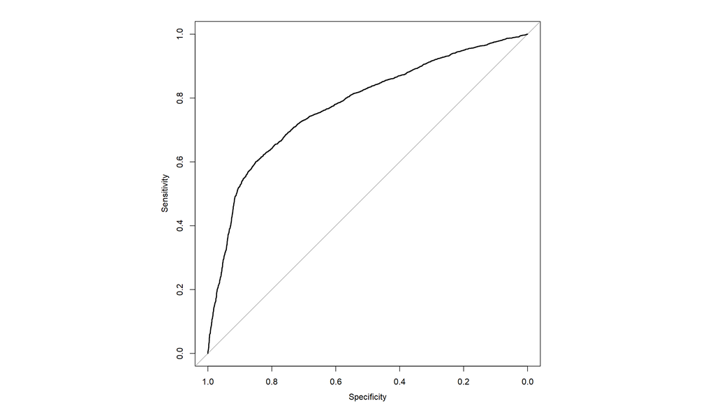

```r
# Evaluate against train and test sets

# Predict on training data
enet.pred.train <- predict(m.final, X.train, type = "response")

roc <- roc(as.numeric(data_train$purchase), enet.pred.train[, 1])
par(pty = "s")
plot(roc)
```

```r
pROC::auc(roc)
```

```
## Area under the curve: 0.7766
```

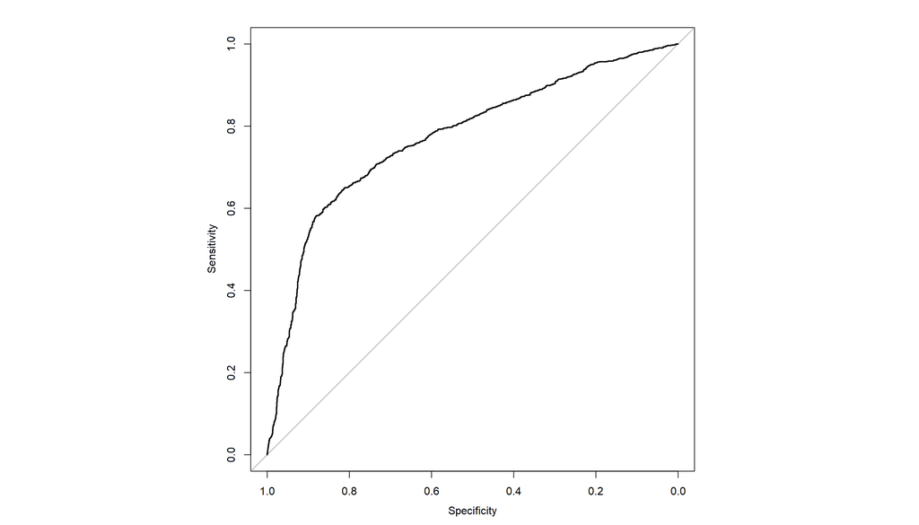

```r
# Predict on test data
enet.pred.test <- predict(m.final, X.test, type = "response")

roc <- roc(as.numeric(data_test$purchase), enet.pred.test[, 1])
par(pty = "s")
plot(roc)
```

```r
pROC::auc(roc)
```

```
## Area under the curve: 0.7733
```

# Task 10: Construct a decision tree.

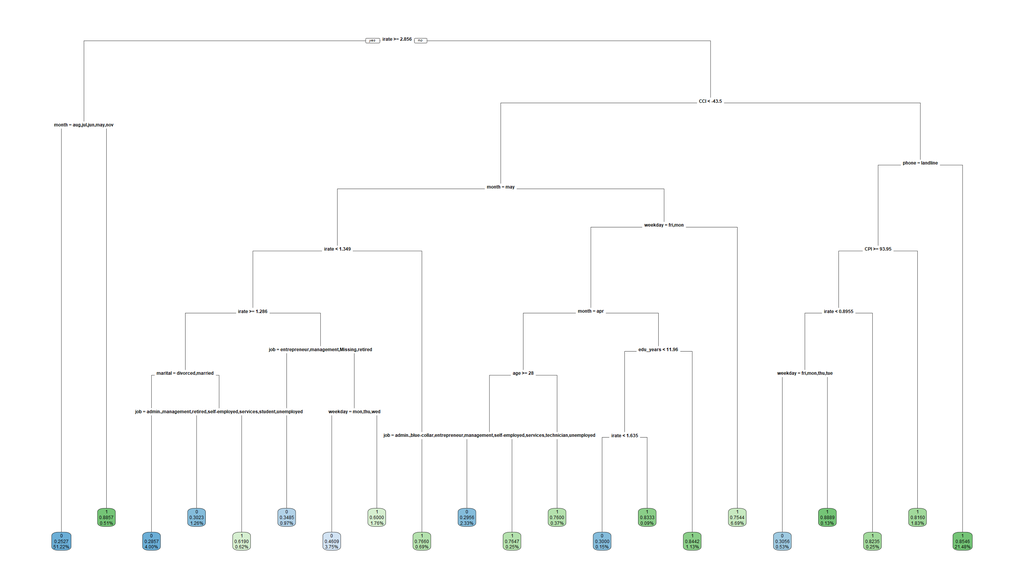

```r
# Load the two needed libraries
library(rpart)
library(rpart.plot)

set.seed(1234)

formula <- "purchase ~ age + job + marital + edu_years + housing + loan + phone + month + weekday + CPI + CCI + irate"

tree1 <- rpart(formula,
  data = data_train, method = "class",
  control = rpart.control(minbucket = 5, cp = 0.0005, maxdepth = 7),
  parms = list(split = "gini")
)

rpart.plot(tree1, type = 0, digits = 4)
```

```r
# Obtain predicted probabilities for train and for test.
pred.prob.tr <- predict(tree1, type = "prob")
pred.prob.te <- predict(tree1, type = "prob", newdata = data_test)

# Construct ROC and calculate AUC for the training data.
library(pROC)
print("Training ROC and AUC")
```

```
## [1] "Training ROC and AUC"
```

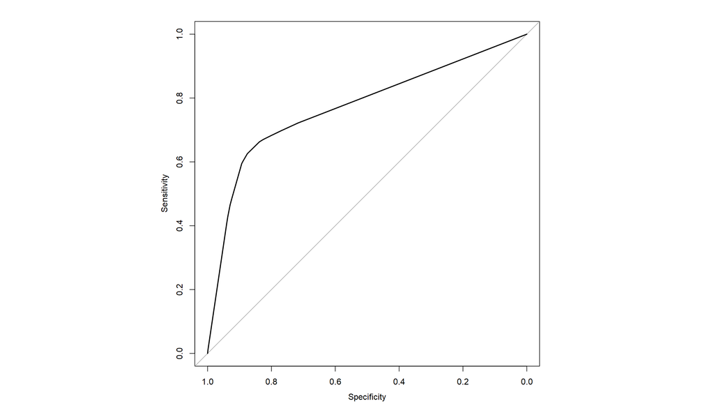

```r
roc <- roc(data_train$purchase, pred.prob.tr[, "1"])
par(pty = "s")
plot(roc)
```

```r
pROC::auc(roc)
```

```
## Area under the curve: 0.7722
```

```r
# Do the same for test.
print("Test ROC and AUC")
```

```
## [1] "Test ROC and AUC"
```

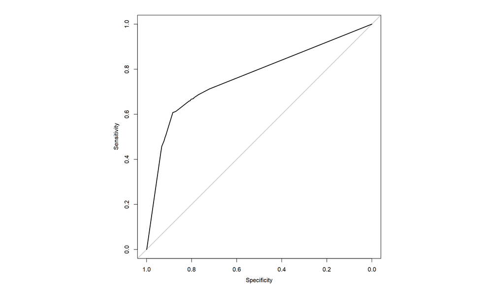

```r
roc2 <- roc(data_test$purchase, pred.prob.te[, "1"])
par(pty = "s")
plot(roc2)
```

```r
pROC::auc(roc2)
```

```
## Area under the curve: 0.7661
```

# Task 11: Employ cost-complexity pruning to construct a smaller tree.

```r
tree1$cptable # This code displays the complexity parameter table for tree1.
```

```
##              CP nsplit rel error    xerror       xstd
## 1  0.3879093199      0 1.0000000 1.0000000 0.01297133
## 2  0.0207808564      1 0.6120907 0.6120907 0.01173870
## 3  0.0085012594      3 0.5705290 0.5683249 0.01147131
## 4  0.0078715365      4 0.5620277 0.5645466 0.01144678
## 5  0.0067695214      5 0.5541562 0.5566751 0.01139492
## 6  0.0040931990      7 0.5406171 0.5516373 0.01136119
## 7  0.0028337531      8 0.5365239 0.5500630 0.01135056
## 8  0.0025188917      9 0.5336902 0.5506927 0.01135481
## 9  0.0015743073     12 0.5261335 0.5510076 0.01135694
## 10 0.0011020151     14 0.5229849 0.5525819 0.01136754
## 11 0.0006297229     18 0.5185768 0.5557305 0.01138863
## 12 0.0005000000     20 0.5173174 0.5607683 0.01142201
```

```r
# Select the optimal pruning parameter from the table.
```

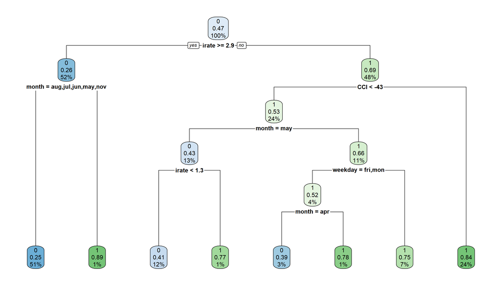

```r
# Replace XX in the code below with the selected complexity parameter.
tree2 <- prune(tree1, cp =  0.0061359346 , "CP")

# Show the pruned tree.
rpart.plot(tree2)
```

```r
# Obtain predicted probabilities for train and for test.
pred.prune.prob.tr <- predict(tree2, type = "prob")
pred.prune.prob.te <- predict(tree2, type = "prob", newdata = data_test)

# Construct ROC and calculate AUC for the training data.
library(pROC)
print("Training ROC and AUC")
```

```
## [1] "Training ROC and AUC"
```

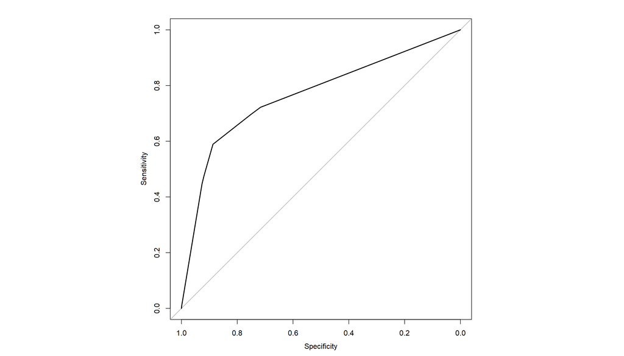

```r
roc <- roc(data_train$purchase, pred.prune.prob.tr[, "1"])
par(pty = "s")
plot(roc)
```

```r
pROC::auc(roc)
```

```
## Area under the curve: 0.7657
```

```r
# Do the same for test.
print("Test ROC and AUC")
```

```
## [1] "Test ROC and AUC"
```

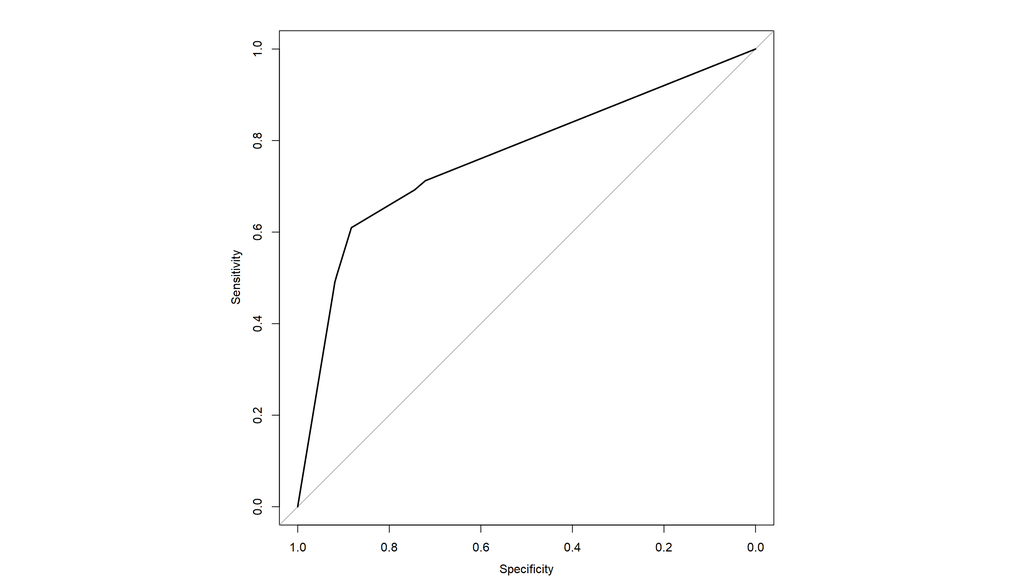

```r
roc2 <- roc(data_test$purchase, pred.prune.prob.te[, "1"])
par(pty = "s")
plot(roc2)
```

```r
pROC::auc(roc2)
```

```
## Area under the curve: 0.7636
```